# Spatial Models

Friedrich

February 19, 2015

**Q1 Examine if there is evidence of spatial dependence in a rare and a common species in the BCI tree dataset**

*There is evidence for spatial dependance in both rare and common species.*

**Common Species** (>100 observations)  
-Trichilia.tuberculata (Tt) difference in abundance **increases** with an increase in distance.  
-Oenocarpus.mapora (Om) difference in abundance **increases** with an increase in distance.  
-Ocotea.whitei (Ow) difference in abundance **increases** with an increase in distance.

**Rare Species** (<100 observations)  
-Luehea.seemannii (Ls) difference in abundance **decreases** with an increase in distance.  
-Hieronyma.alchorneoides (Ha) difference in abundance **decreases** with an increase in distance.  
-Ocotea.puberula (Op) difference in abundance **increases** with an increase in distance.  
-Myrcia.gatunensis (Mg) difference in abundance **increases** with an increase in distance.

```r
library(vegan)
library(nlme)
data(BCI)
## UTM Coordinates (in metres)
BCI_xy = data.frame(x = rep(seq(625754, 626654, by=100), each=5),
                    y = rep(seq(1011569,  1011969, by=100), len=50))
head(BCI_xy)
```

```
##        x       y
## 1 625754 1011569
## 2 625754 1011669
## 3 625754 1011769
## 4 625754 1011869
## 5 625754 1011969
## 6 625854 1011569
```

```r
sa = apply(BCI, 2, function(x) sum(x))
head(sa)
```

```
##    Abarema.macradenia    Acacia.melanoceras Acalypha.diversifolia
##                     1                     3                     2
## Acalypha.macrostachya        Adelia.triloba  Aegiphila.panamensis
##                     1                    92                    23
```

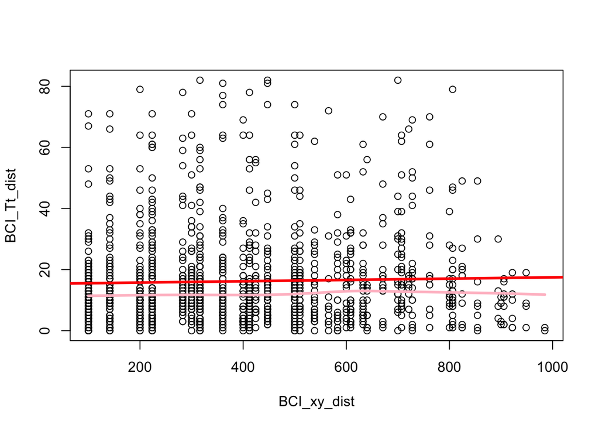

```r
# Trichilia.tuberculata has 1681 counts
# Oenocarpus.mapora has 788 counts
# Ocotea.whitei has 184 counts
# Luehea.seemannii has 93 counts
# Hieronyma.alchorneoides has 41 counts
# Ocotea.puberula has 22 counts
# Myrcia.gatunensis has 5 counts

BCI_Tt_dist = dist(BCI$Trichilia.tuberculata)
BCI_Om_dist = dist(BCI$Oenocarpus.mapora)
BCI_Ow_dist = dist(BCI$Ocotea.whitei)
BCI_Ls_dist = dist(BCI$Luehea.seemannii)
BCI_Ha_dist = dist(BCI$Hieronyma.alchorneoides)
BCI_Op_dist = dist(BCI$Ocotea.puberula)
BCI_Mg_dist = dist(BCI$Myrcia.gatunensis)
BCI_xy_dist = dist(BCI_xy)

plot(BCI_xy_dist, BCI_Tt_dist)
abline(lm(BCI_Tt_dist ~ BCI_xy_dist), lwd=3, col='red')
lines(lowess(BCI_xy_dist, BCI_Tt_dist), lwd=3, col='pink')
```

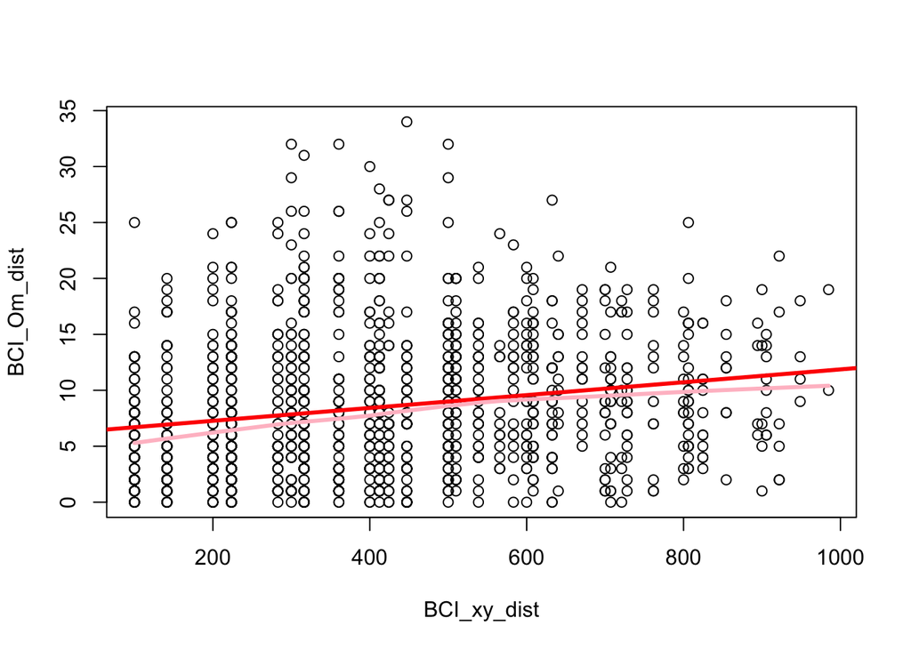

```r
plot(BCI_xy_dist, BCI_Om_dist)
abline(lm(BCI_Om_dist ~ BCI_xy_dist), lwd=3, col='red')
lines(lowess(BCI_xy_dist, BCI_Om_dist), lwd=3, col='pink')
```

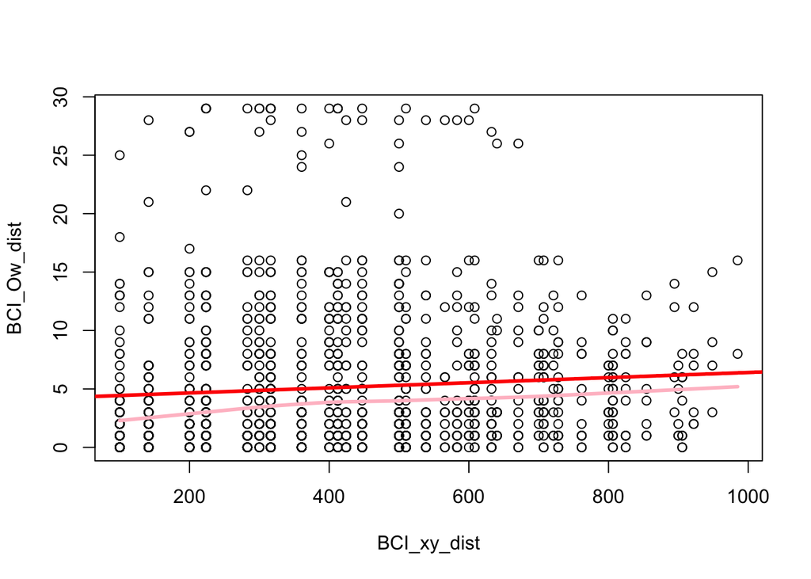

```r
plot(BCI_xy_dist, BCI_Ow_dist)
abline(lm(BCI_Ow_dist ~ BCI_xy_dist), lwd=3, col='red')
lines(lowess(BCI_xy_dist, BCI_Ow_dist), lwd=3, col='pink')
```

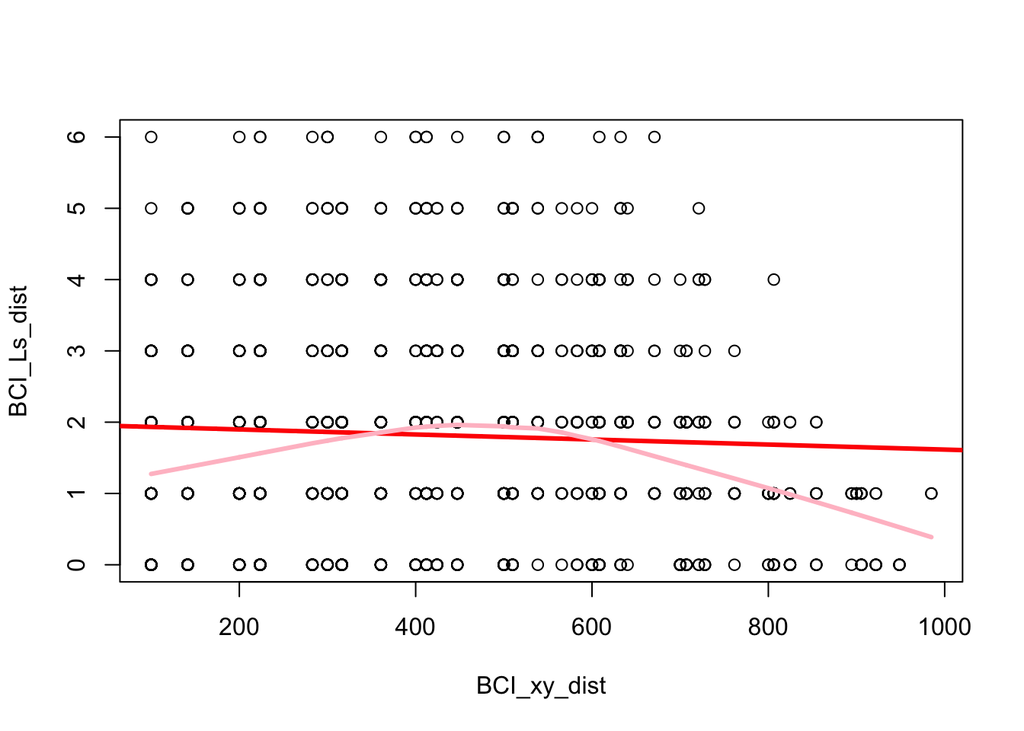

```r
plot(BCI_xy_dist, BCI_Ls_dist)
abline(lm(BCI_Ls_dist ~ BCI_xy_dist), lwd=3, col='red')
lines(lowess(BCI_xy_dist, BCI_Ls_dist), lwd=3, col='pink')
```

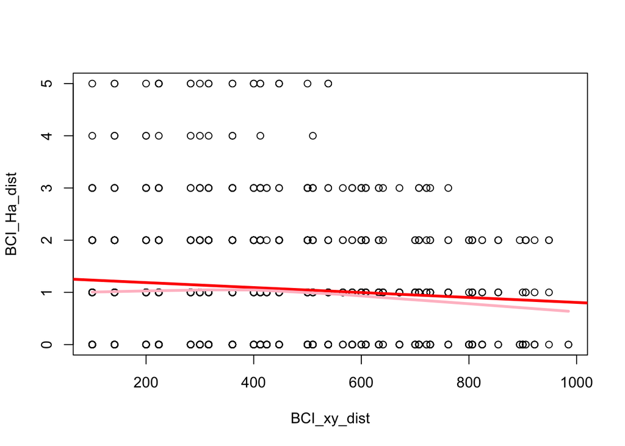

```r
plot(BCI_xy_dist, BCI_Ha_dist)
abline(lm(BCI_Ha_dist ~ BCI_xy_dist), lwd=3, col='red')
lines(lowess(BCI_xy_dist, BCI_Ha_dist), lwd=3, col='pink')
```

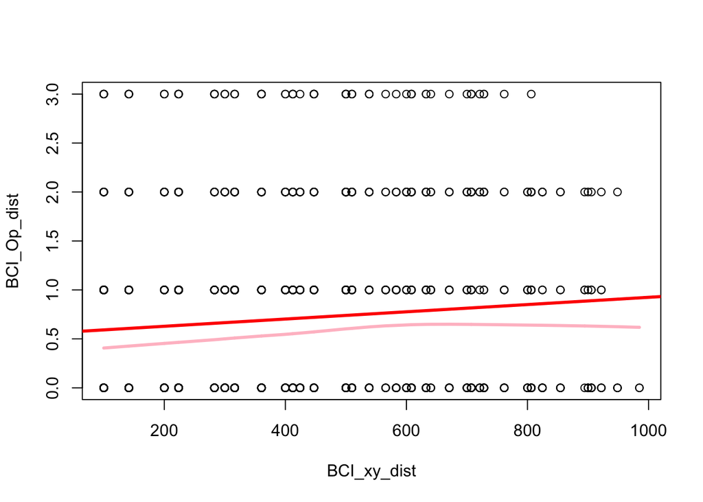

```r
plot(BCI_xy_dist, BCI_Op_dist)
abline(lm(BCI_Op_dist ~ BCI_xy_dist), lwd=3, col='red')
lines(lowess(BCI_xy_dist, BCI_Op_dist), lwd=3, col='pink')
```

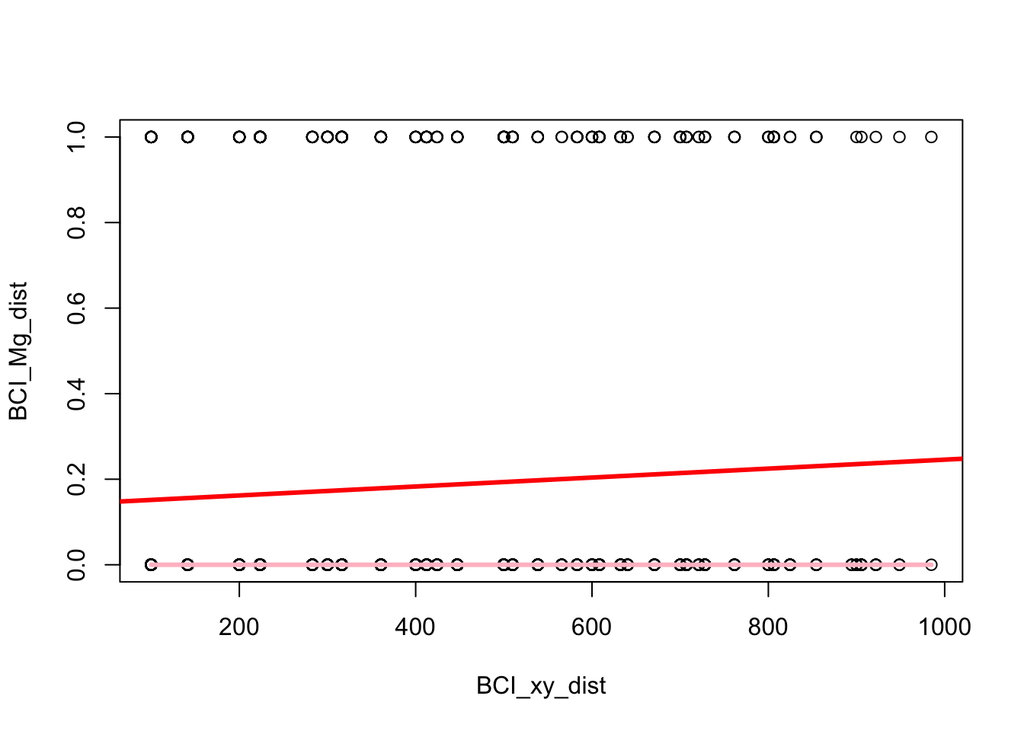

```r
plot(BCI_xy_dist, BCI_Mg_dist)
abline(lm(BCI_Mg_dist ~ BCI_xy_dist), lwd=3, col='red')
lines(lowess(BCI_xy_dist, BCI_Mg_dist), lwd=3, col='pink')
```

**Q2 Build two generalized linear models to predict the abundance of the species Drypetes standleyi using the abundance of other tree species in the study site. Specifically examine the following species as predictor variables:**

```r
sp_p_ids = c("Cordia.lasiocalyx", "Hirtella.triandra",
           "Picramnia.latifolia", "Quassia.amara",
           "Tabernaemontana.arborea", "Trattinnickia.aspera",
           "Xylopia.macrantha")
```

**Note renaming the species ids to something a little easier to work with like “sp_a”, “sp_b” will make model construction a little less cumbersome.**

**Model 1: only include a single species as a predictor variable**

```r
sp_ids = BCI[ , c("Drypetes.standleyi", "Cordia.lasiocalyx", "Hirtella.triandra",
           "Picramnia.latifolia", "Quassia.amara",
           "Tabernaemontana.arborea", "Trattinnickia.aspera",
           "Xylopia.macrantha")]
sp_dat = data.frame(sp_ids, BCI_xy)

sa_lm_one = gls(Drypetes.standleyi ~ Cordia.lasiocalyx, data=sp_dat)
```

**Model 2: include all of the species as predictor variables**

```r
sa_lm_two = gls(Drypetes.standleyi ~ Cordia.lasiocalyx+Hirtella.triandra+Picramnia.latifolia+
            Quassia.amara+Tabernaemontana.arborea+Trattinnickia.aspera+
                Xylopia.macrantha, data=sp_dat)
```

**With both models examine the spatial dependence of the residuals using the function Variogram. Model the spatial dependence in the residuals using one of the error structures available.**

Model 1

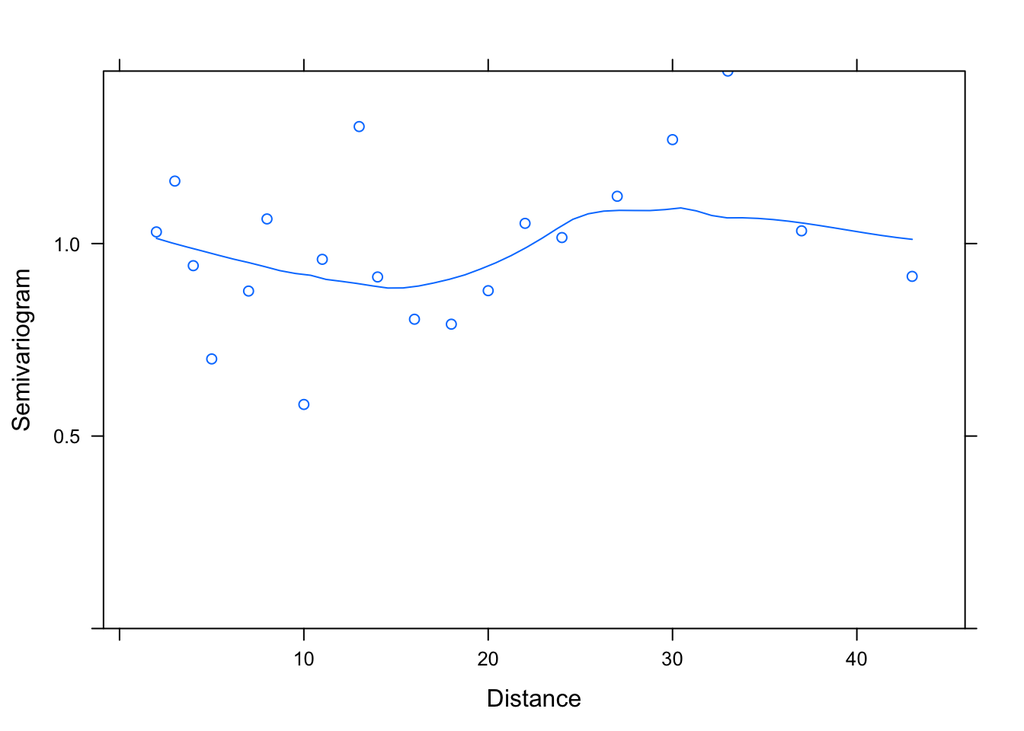

```r
plot(Variogram(sa_lm_one, resType='n'))
```

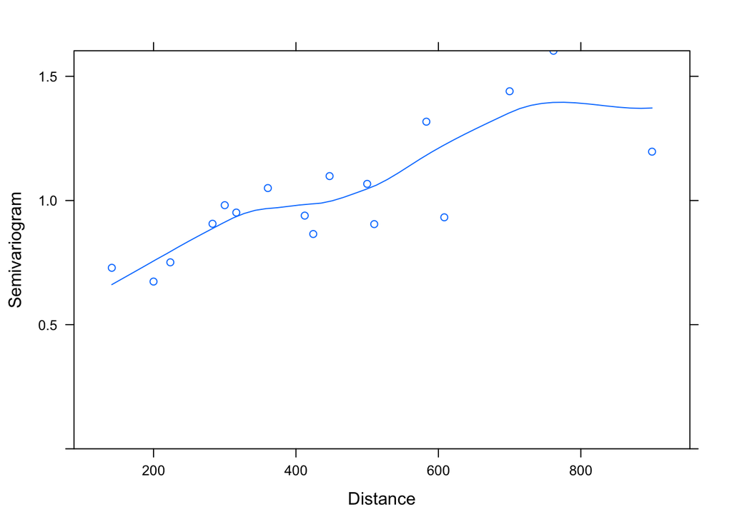

```r
plot(Variogram(sa_lm_one, form=~x + y))
```

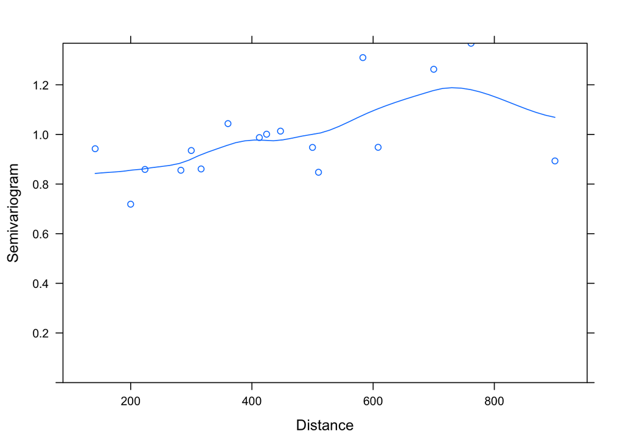

```r
sa_spher_one = update(sa_lm_one, corr=corSpher(c(500, .6), form=~x + y, nugget=T))
plot(Variogram(sa_spher_one, resType='n'))
```

Model 2

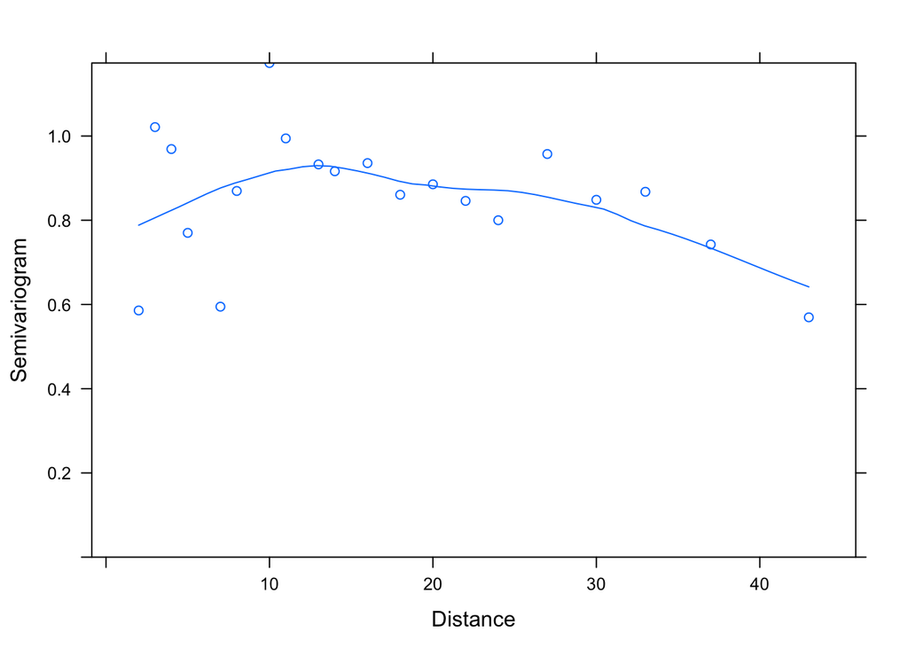

```r
plot(Variogram(sa_lm_two, resType='n'))
```

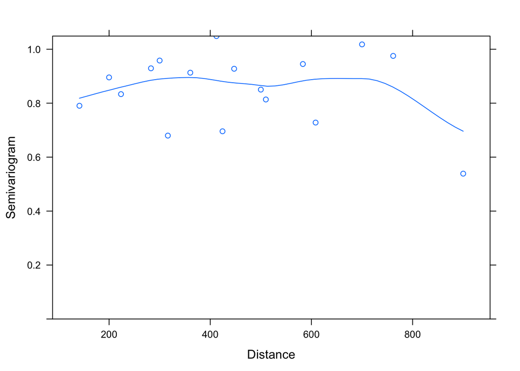

```r
plot(Variogram(sa_lm_two, form=~x + y))
```

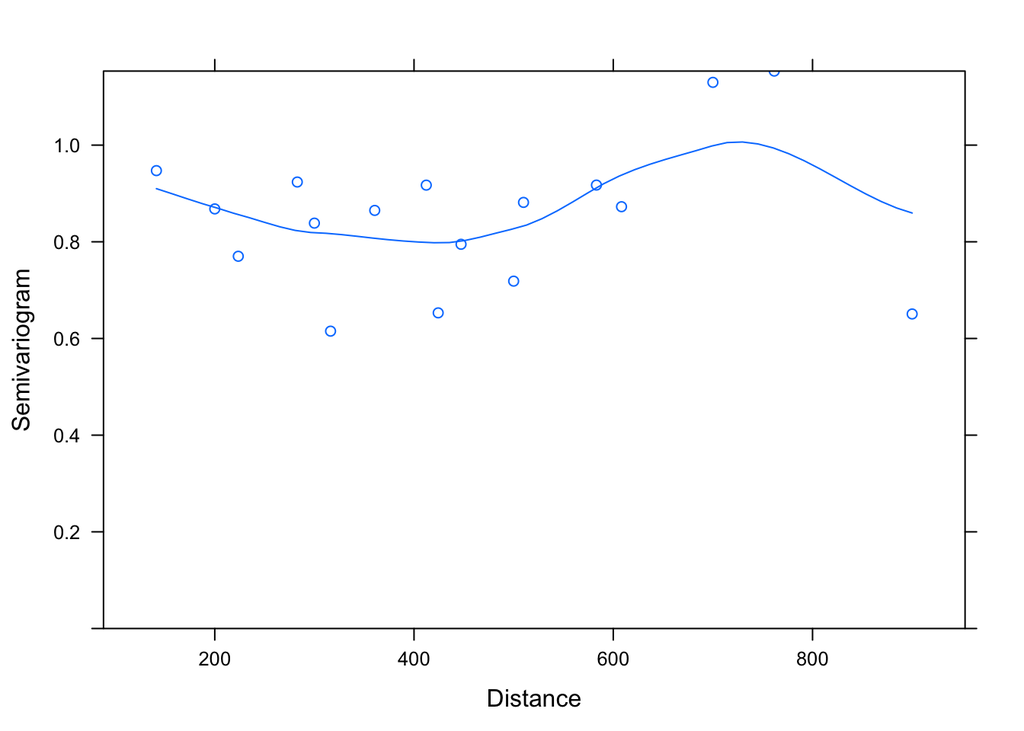

```r
sa_spher_two = update(sa_lm_two, corr=corSpher(c(500, .6), form=~x + y, nugget=T))
plot(Variogram(sa_spher_two, resType='n'))
```

**Did including the spatial error term have a large impact on the coefficients of the model?**

*Yes, the coefficient for Cordia.lasiocalyx in Model 1 changed from 1.165220 to 0.17306. Changes in Model 2 after including an error term can be observed to be occuring at a similar magnitude.*

```r
summary(sa_lm_one)
```

```
## Generalized least squares fit by REML
##   Model: Drypetes.standleyi ~ Cordia.lasiocalyx
##   Data: sp_dat
##        AIC      BIC    logLik
##   335.1246 340.7382 -164.5623
##
## Coefficients:
##                       Value Std.Error   t-value p-value
## (Intercept)       -2.782803 1.9173184 -1.451404  0.1532
## Cordia.lasiocalyx  1.165220 0.2292289  5.083217  0.0000
##
##  Correlation:
##                   (Intr)
## Cordia.lasiocalyx -0.87
##
## Standardized residuals:
##        Min         Q1        Med         Q3        Max
## -1.8757378 -0.4356989 -0.1061361  0.1804392  4.5135685
##
## Residual standard error: 6.675561
## Degrees of freedom: 50 total; 48 residual
```

```r
summary(sa_spher_one)
```

```
## Generalized least squares fit by REML
##   Model: Drypetes.standleyi ~ Cordia.lasiocalyx
##   Data: sp_dat
##        AIC      BIC    logLik
##   311.0547 320.4107 -150.5274
##
## Correlation Structure: Spherical spatial correlation
##  Formula: ~x + y
##  Parameter estimate(s):
##        range       nugget
## 2.086214e+06 4.445933e-05
##
## Coefficients:
##                      Value Std.Error   t-value p-value
## (Intercept)       10.70637  414.9166 0.0258037  0.9795
## Cordia.lasiocalyx  0.17306    0.2146 0.8065661  0.4239
##
##  Correlation:
##                   (Intr)
## Cordia.lasiocalyx -0.006
##
## Standardized residuals:
##         Min          Q1         Med          Q3         Max
## -0.03038511 -0.02675943 -0.02264688 -0.01237116  0.06400625
##
## Residual standard error: 415.0068
## Degrees of freedom: 50 total; 48 residual
```

```r
summary(sa_lm_two)
```

```
## Generalized least squares fit by REML
##   Model: Drypetes.standleyi ~ Cordia.lasiocalyx + Hirtella.triandra +      Picramnia.latifolia + Quassia.amara + Tabernaemontana.arborea +      Trattinnickia.aspera + Xylopia.macrantha
##   Data: sp_dat
##        AIC      BIC    logLik
##   307.1163 322.7554 -144.5582
##
## Coefficients:
##                             Value Std.Error   t-value p-value
## (Intercept)             -1.051752 2.1175346 -0.496687  0.6220
## Cordia.lasiocalyx        0.428920 0.2039316  2.103255  0.0415
## Hirtella.triandra        0.122279 0.0802638  1.523462  0.1351
## Picramnia.latifolia      0.662259 0.6358905  1.041468  0.3036
## Quassia.amara            4.085661 2.2842770  1.788602  0.0809
## Tabernaemontana.arborea -0.249725 0.1491192 -1.674667  0.1014
## Trattinnickia.aspera     1.349323 0.7147412  1.887848  0.0660
## Xylopia.macrantha        0.548832 0.1468772  3.736672  0.0006
##
##  Correlation:
##                         (Intr) Crd.ls Hrtll. Pcrmn. Qss.mr Tbrnm. Trttn.
## Cordia.lasiocalyx       -0.618
## Hirtella.triandra       -0.212 -0.354
## Picramnia.latifolia      0.025 -0.019 -0.381
## Quassia.amara            0.163 -0.378  0.307 -0.302
## Tabernaemontana.arborea -0.708  0.245  0.163 -0.113  0.148
## Trattinnickia.aspera    -0.139  0.187 -0.311  0.308 -0.708 -0.144
## Xylopia.macrantha       -0.140 -0.125  0.156 -0.463  0.314  0.279 -0.294
##
## Standardized residuals:
##         Min          Q1         Med          Q3         Max
## -1.87708765 -0.42701500 -0.04032793  0.23615609  3.38768871
##
## Residual standard error: 4.539713
## Degrees of freedom: 50 total; 42 residual
```

```r
summary(sa_spher_two)
```

```
## Generalized least squares fit by REML
##   Model: Drypetes.standleyi ~ Cordia.lasiocalyx + Hirtella.triandra +      Picramnia.latifolia + Quassia.amara + Tabernaemontana.arborea +      Trattinnickia.aspera + Xylopia.macrantha
##   Data: sp_dat
##        AIC      BIC    logLik
##   304.2308 323.3451 -141.1154
##
## Correlation Structure: Spherical spatial correlation
##  Formula: ~x + y
##  Parameter estimate(s):
##       range      nugget
## 463.5527870   0.1373768
##
## Coefficients:
##                             Value Std.Error  t-value p-value
## (Intercept)             1.0243906  3.207264 0.319397  0.7510
## Cordia.lasiocalyx       0.1672229  0.189385 0.882978  0.3823
## Hirtella.triandra       0.0401933  0.098146 0.409525  0.6842
## Picramnia.latifolia     0.2927577  0.532492 0.549788  0.5854
## Quassia.amara           1.8065995  1.900086 0.950799  0.3471
## Tabernaemontana.arborea 0.0183527  0.139977 0.131113  0.8963
## Trattinnickia.aspera    1.7782367  0.557665 3.188721  0.0027
## Xylopia.macrantha       0.4007505  0.160031 2.504207  0.0162
##
##  Correlation:
##                         (Intr) Crd.ls Hrtll. Pcrmn. Qss.mr Tbrnm. Trttn.
## Cordia.lasiocalyx       -0.386
## Hirtella.triandra       -0.438 -0.084
## Picramnia.latifolia      0.070 -0.048 -0.398
## Quassia.amara           -0.023 -0.325  0.298 -0.196
## Tabernaemontana.arborea -0.414 -0.012  0.264 -0.212  0.124
## Trattinnickia.aspera    -0.101  0.163 -0.249  0.253 -0.645 -0.054
## Xylopia.macrantha       -0.123 -0.115 -0.074  0.037  0.272  0.136 -0.165
##
## Standardized residuals:
##        Min         Q1        Med         Q3        Max
## -1.2789441 -0.5835571 -0.3264563  0.3557053  3.3175844
##
## Residual standard error: 5.909998
## Degrees of freedom: 50 total; 42 residual
```

**Did including the spatial error terms significantly improve model fit (use function anova to carry out model comparison)?**

*Yes, including the corSpher error term lowered the AIC value in both Model 1 and Model 2. Model 1 was improved from AIC 335.1246 to AIC 311.0547 with the error term, while Model 2 was improved by only AIC 307.1163 to AIC 304.2308 using the error term. Model 2 only experienced a 3 point AIC drop, while Model 1 experienced a 24 point AIC drop.*

```r
anova(sa_lm_one, sa_spher_one)
```

```
##              Model df      AIC      BIC    logLik   Test  L.Ratio p-value
## sa_lm_one        1  3 335.1246 340.7382 -164.5623
## sa_spher_one     2  5 311.0547 320.4107 -150.5274 1 vs 2 28.06989  <.0001
```

```r
anova(sa_lm_two, sa_spher_two)
```

```
##              Model df      AIC      BIC    logLik   Test  L.Ratio p-value
## sa_lm_two        1  9 307.1163 322.7554 -144.5582
## sa_spher_two     2 11 304.2308 323.3451 -141.1154 1 vs 2 6.885588   0.032
```

**Explain why modeling the spatial errors has a large influence in the first model but not in the second model.**

*The presence of mutiple spatially distributed predictor variables in Model 2 is likely to be explaining spatial error present in Model 1, unexplained by just Cordia.lasiocalyx. In other words, the `corSpher()` error term captures more unexplained error in Model 1 because only Cordia.lasiocalyx is used as a predictor. With the introduction of many more spatially fixed predictors, spatial error is inherently reduced in Model 2, leaving less unexplained spatial error to be captured by `corSpher()`.*